# Data 608 HW 1

# Principles of Data Visualization and Introduction to ggplot2

I have provided you with data about the 5,000 fastest growing companies in the US, as compiled by Inc. magazine. lets read this in:

```r
inc <- read.csv("https://raw.githubusercontent.com/charleyferrari/CUNY_DATA_608/master/module1/Data/inc5000_data.csv", header= TRUE)
```

And lets preview this data:

```r
library(kableExtra)

kable(head(inc))
```

| Rank | Name | Growth_Rate | Revenue | Industry | Employees | City | State |
| --- | --- | --- | --- | --- | --- | --- | --- |
| 1 | Fuhu | 421.48 | 1.179e+08 | Consumer Products & Services | 104 | El Segundo | CA |
| 2 | FederalConference.com | 248.31 | 4.960e+07 | Government Services | 51 | Dumfries | VA |
| 3 | The HCI Group | 245.45 | 2.550e+07 | Health | 132 | Jacksonville | FL |
| 4 | Bridger | 233.08 | 1.900e+09 | Energy | 50 | Addison | TX |
| 5 | DataXu | 213.37 | 8.700e+07 | Advertising & Marketing | 220 | Boston | MA |
| 6 | MileStone Community Builders | 179.38 | 4.570e+07 | Real Estate | 63 | Austin | TX |

```r
summary(inc)
```

```
##       Rank                          Name       Growth_Rate
##  Min.   :   1   (Add)ventures         :   1   Min.   :  0.340
##  1st Qu.:1252   @Properties           :   1   1st Qu.:  0.770
##  Median :2502   1-Stop Translation USA:   1   Median :  1.420
##  Mean   :2502   110 Consulting        :   1   Mean   :  4.612
##  3rd Qu.:3751   11thStreetCoffee.com  :   1   3rd Qu.:  3.290
##  Max.   :5000   123 Exteriors         :   1   Max.   :421.480
##                 (Other)               :4995
##     Revenue                                  Industry      Employees
##  Min.   :2.000e+06   IT Services                 : 733   Min.   :    1.0
##  1st Qu.:5.100e+06   Business Products & Services: 482   1st Qu.:   25.0
##  Median :1.090e+07   Advertising & Marketing     : 471   Median :   53.0
##  Mean   :4.822e+07   Health                      : 355   Mean   :  232.7
##  3rd Qu.:2.860e+07   Software                    : 342   3rd Qu.:  132.0
##  Max.   :1.010e+10   Financial Services          : 260   Max.   :66803.0
##                      (Other)                     :2358   NA's   :12
##             City          State
##  New York     : 160   CA     : 701
##  Chicago      :  90   TX     : 387
##  Austin       :  88   NY     : 311
##  Houston      :  76   VA     : 283
##  San Francisco:  75   FL     : 282
##  Atlanta      :  74   IL     : 273
##  (Other)      :4438   (Other):2764
```

Think a bit on what these summaries mean. Use the space below to add some more relevant non-visual exploratory information you think helps you understand this data:

```r
#add the tidyverse library
library(tidyverse)
# Count the number of obervations for each variable
inc %>%
  count()
```

```
## # A tibble: 1 x 1
##       n
##   <int>
## 1  5001
```

```r
#take a look at the structure of the data
kable(str(inc))
```

```
## 'data.frame':    5001 obs. of  8 variables:
##  $ Rank       : int  1 2 3 4 5 6 7 8 9 10 ...
##  $ Name       : Factor w/ 5001 levels "(Add)ventures",..: 1770 1633 4423 690 1198 2839 4733 1468 1869 4968 ...
##  $ Growth_Rate: num  421 248 245 233 213 ...
##  $ Revenue    : num  1.18e+08 4.96e+07 2.55e+07 1.90e+09 8.70e+07 ...
##  $ Industry   : Factor w/ 25 levels "Advertising & Marketing",..: 5 12 13 7 1 20 10 1 5 21 ...
##  $ Employees  : int  104 51 132 50 220 63 27 75 97 15 ...
##  $ City       : Factor w/ 1519 levels "Acton","Addison",..: 391 365 635 2 139 66 912 1179 131 1418 ...
##  $ State      : Factor w/ 52 levels "AK","AL","AR",..: 5 47 10 45 20 45 44 5 46 41 ...
```

```r
#count all the NA values in the dataframe
cInc <- inc %>%
  is.na() %>%
  sum()

kable(cInc)
```

| x |
| --- |
| 12 |

```r
#Count NAs in each column
kable(sapply(inc, function(x) sum(is.na(x))))
```

|  | x |
| --- | --- |
| Rank | 0 |
| Name | 0 |
| Growth_Rate | 0 |
| Revenue | 0 |
| Industry | 0 |
| Employees | 12 |
| City | 0 |
| State | 0 |

```r
#count the number of unique types of responses in categorical variables
kable(sapply(inc, function(x) length(unique(x))))
```

|  | x |
| --- | --- |
| Rank | 4999 |
| Name | 5001 |
| Growth_Rate | 1147 |
| Revenue | 1069 |
| Industry | 25 |
| Employees | 692 |
| City | 1519 |
| State | 52 |

```r
#Peaking at rows with the same ranking

#values of Rank that are duplicated as a list
dups <- unlist(as.list(inc$Rank[duplicated(inc$Rank)]))

#filters the rows with duplicated rankings
fildups <- inc %>%
  filter(Rank %in% dups)

#display
kable(head(fildups))
```

| Rank | Name | Growth_Rate | Revenue | Industry | Employees | City | State |
| --- | --- | --- | --- | --- | --- | --- | --- |
| 3424 | Stemp Systems Group | 19.37 | 6800000 | IT Services | 39 | Long Island City | NY |
| 3424 | Total Beverage Solution | 0.90 | 41500000 | Food & Beverage | 35 | Mt. Pleasant | SC |
| 5000 | INE | 0.34 | 6800000 | IT Services | 35 | Bellevue | WA |
| 5000 | ALL4 | 0.34 | 4700000 | Environmental Services | 34 | Kimberton | PA |

```r
#Little bit of a deeper dive into Growth Rates
kable(head(inc %>% arrange(desc(Growth_Rate))))
```

| Rank | Name | Growth_Rate | Revenue | Industry | Employees | City | State |
| --- | --- | --- | --- | --- | --- | --- | --- |
| 1 | Fuhu | 421.48 | 1.179e+08 | Consumer Products & Services | 104 | El Segundo | CA |
| 2 | FederalConference.com | 248.31 | 4.960e+07 | Government Services | 51 | Dumfries | VA |
| 3 | The HCI Group | 245.45 | 2.550e+07 | Health | 132 | Jacksonville | FL |
| 4 | Bridger | 233.08 | 1.900e+09 | Energy | 50 | Addison | TX |
| 5 | DataXu | 213.37 | 8.700e+07 | Advertising & Marketing | 220 | Boston | MA |
| 6 | MileStone Community Builders | 179.38 | 4.570e+07 | Real Estate | 63 | Austin | TX |

```r
#take a better look at correlated variables
corInc <- inc %>%
  select_if(is.numeric) %>%
  cor()

kable(corInc)
```

|  | Rank | Growth_Rate | Revenue | Employees |
| --- | --- | --- | --- | --- |
| Rank | 1.0000000 | -0.3976698 | 0.0821068 | NA |
| Growth_Rate | -0.3976698 | 1.0000000 | 0.0063041 | NA |
| Revenue | 0.0821068 | 0.0063041 | 1.0000000 | NA |
| Employees | NA | NA | NA | 1 |

```r
library(psych)

#Some quick statistical information not included in summary() function
kable(describe(inc))
```

|  | vars | n | mean | sd | median | trimmed | mad | min | max | range | skew | kurtosis | se |
| --- | --- | --- | --- | --- | --- | --- | --- | --- | --- | --- | --- | --- | --- |
| Rank | 1 | 5001 | 2.501641e+03 | 1.443506e+03 | 2.502e+03 | 2.501731e+03 | 1.853250e+03 | 1.0e+00 | 5.0000e+03 | 4.9990e+03 | -0.0004896 | -1.200432 | 2.041222e+01 |
| Name* | 2 | 5001 | 2.501000e+03 | 1.443809e+03 | 2.501e+03 | 2.501000e+03 | 1.853250e+03 | 1.0e+00 | 5.0010e+03 | 5.0000e+03 | 0.0000000 | -1.200720 | 2.041650e+01 |
| Growth_Rate | 3 | 5001 | 4.611826e+00 | 1.412369e+01 | 1.420e+00 | 2.136756e+00 | 1.215732e+00 | 3.4e-01 | 4.2148e+02 | 4.2114e+02 | 12.5495059 | 242.336616 | 1.997192e-01 |
| Revenue | 4 | 5001 | 4.822254e+07 | 2.405423e+08 | 1.090e+07 | 1.733497e+07 | 1.067472e+07 | 2.0e+06 | 1.0100e+10 | 1.0098e+10 | 22.1744453 | 722.656318 | 3.401441e+06 |
| Industry* | 5 | 5001 | 1.210038e+01 | 7.328351e+00 | 1.300e+01 | 1.205499e+01 | 8.895600e+00 | 1.0e+00 | 2.5000e+01 | 2.4000e+01 | -0.1012333 | -1.184515 | 1.036282e-01 |
| Employees | 6 | 4989 | 2.327180e+02 | 1.353128e+03 | 5.300e+01 | 8.177511e+01 | 5.337360e+01 | 1.0e+00 | 6.6803e+04 | 6.6802e+04 | 29.8104167 | 1268.671130 | 1.915720e+01 |
| City* | 7 | 5001 | 7.320010e+02 | 4.411164e+02 | 7.610e+02 | 7.317383e+02 | 6.049008e+02 | 1.0e+00 | 1.5190e+03 | 1.5180e+03 | -0.0420954 | -1.264827 | 6.237704e+00 |
| State* | 8 | 5001 | 2.480324e+01 | 1.563706e+01 | 2.300e+01 | 2.444364e+01 | 1.927380e+01 | 1.0e+00 | 5.2000e+01 | 5.1000e+01 | 0.1190507 | -1.461030 | 2.211193e-01 |

## Question 1

Create a graph that shows the distribution of companies in the dataset by State (ie how many are in each state). There are a lot of States, so consider which axis you should use. This visualization is ultimately going to be consumed on a ‘portrait’ oriented screen (ie taller than wide), which should further guide your layout choices.

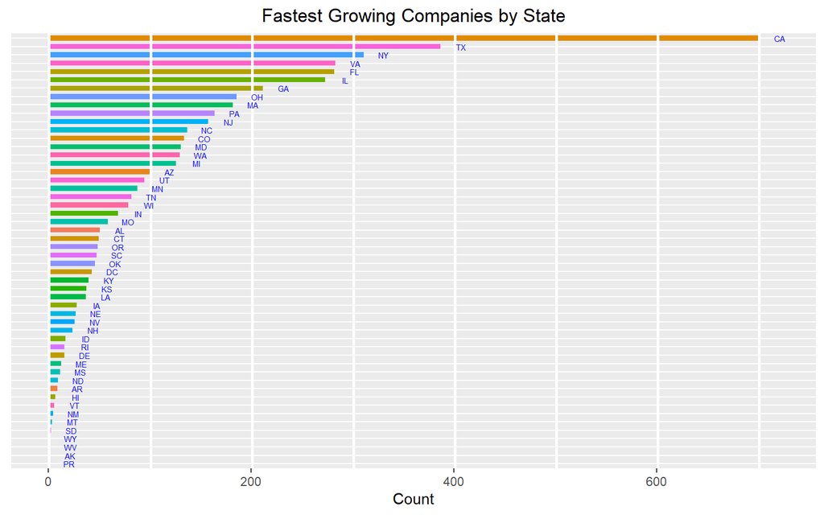

```r
library(ggplot2)

q1 <- inc%>%
  group_by(State)%>%
  count(State)%>% #counts the number of company in each state
  arrange(desc(n))%>% #arranges them in decending order
  as_tibble(q1) #changes the format of the data for ggplot()


#graph with count of companies in each state
ggplot(q1, aes(x=reorder(State,n), y=n, fill = State))+
  geom_bar(stat="identity", width=.6, show.legend = FALSE)+
  geom_hline(yintercept=seq(1,800,100), col="white", lwd=1)+
  theme(panel.grid.major.x = element_blank())+
  coord_flip()+
  geom_text(aes(x = State, label = State, y = n +20), colour="blue", size = 2)+
  labs(y = "Count", x ="State", color="legend", title = "Fastest Growing Companies by State") +
  theme(axis.text.y=element_blank()
        ,axis.title.y=element_blank(),
        axis.ticks.y=element_blank(),
        plot.title = element_text(hjust = 0.5))
```

### Approach

We are essentially creating a frequency chart of the number of companies in each state therefore it is appropriate to group the data by state and count the number of companies in each state. Then I use a bar graph to display the counts for each state and arrange them in deecending order so that the state with the greatest number of growing companies is at the top. Since the visualization was meant to be viewed in a portate format I decided to flip the axis of this graph so that more space can be placed between the state columns and therefore make the width less than the height of this vizualization. I then changed the color of each bar to make it easier to compare adjacent bars and included the abreviation for each state next to the bar (rather than on the axis).

## Quesiton 2

Lets dig in on the state with the 3rd most companies in the data set. Imagine you work for the state and are interested in how many people are employed by companies in different industries. Create a plot that shows the average and/or median employment by industry for companies in this state (only use cases with full data, use R’s `complete.cases()` function.) In addition to this, your graph should show how variable the ranges are, and you should deal with outliers.

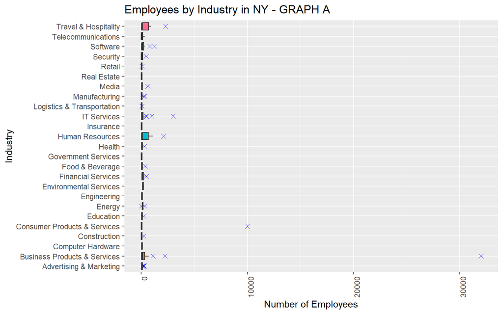

```r
#initial group
NY <- inc %>%
  filter(State== "NY") %>%
  filter(complete.cases(.)) %>%
  group_by(Industry)

#Initial boxplot with outliers
ggplot(NY, aes(Industry, Employees, fill = Industry)) +
  geom_boxplot(outlier.colour="blue",
               outlier.shape=4,
               outlier.size=2,
               show.legend=FALSE) +
   theme(axis.text.x = element_text(angle = 90, hjust = 1)) +
   coord_flip()+
  labs(title="Employees by Industry in NY - GRAPH A", y="Number of Employees")
```

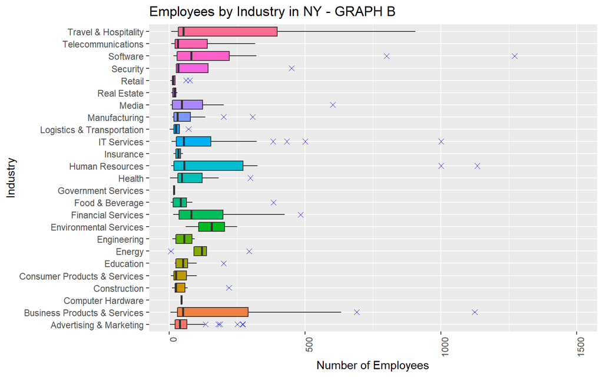

```r
#Boxplot without outliers (ignoring all points greeater than 1500)
ggplot(NY, aes(Industry, Employees, fill = Industry)) +
  geom_boxplot(outlier.colour="blue",
               outlier.shape=4,
               outlier.size=2,
               show.legend=FALSE) +
  ylim(0,1500) +
  theme(axis.text.x = element_text(angle = 90, hjust = 1)) +
  coord_flip()+
  labs(title="Employees by Industry in NY - GRAPH B", y="Number of Employees")
```

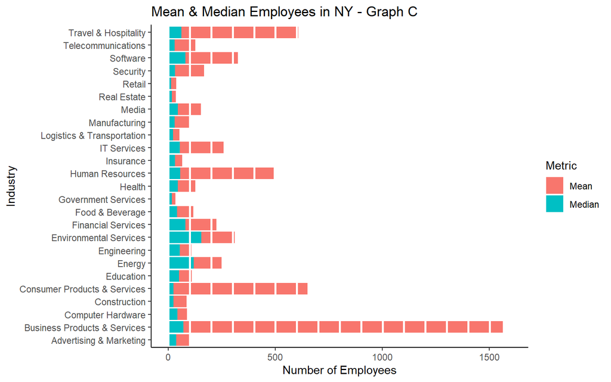

```r
#Specifically compare mean and median
NY2 <- NY%>%
  summarise(IndMean = mean(Employees),
            IndMedian = median(Employees))%>%
  gather(statistic, Employees, IndMean, IndMedian)

#Plot
ggplot(NY2, aes(x=Industry, y=Employees))+
  geom_bar(stat = "identity", aes(fill=statistic))+
  geom_hline(yintercept=seq(1,1700,100), col="white", lwd=1)+
  theme_classic()+
  coord_flip()+
  scale_fill_discrete(name = "Metric", labels = c("Mean", "Median")) +
  labs(title="Mean & Median Employees in NY - Graph C", y="Number of Employees")
```